# Упражнение 9

Дунашов Константин

11 05 2021

Необходимо построить модель на основе SVM для указанной в варианте зависимой переменной.

Данные взять из упражнения №3.

Для модели:

1. Отложить 25% наблюдений в тестовую выборку (ядро генератора случайных чисел указано в варианте к упражнению №3).
2. На обучающей выборке (оставшихся 75% наблюдений) сравнить несколько видов ядер SVM по точности модели (AUC) методом сеточного поиска.
3. Для оптимальной формы ядерной функции на обучающей выборке подобрать оптимальное значение настроечных параметров по минимальной ошибке с перекрёстной проверкой (функция tune).
4. Подогнать лучшую модель на всей обучающей выборке. Построить ROC-кривую и рассчитать матрицу неточностей, чувствительность и специфичность.
5. Сделать прогноз по лучшей модели на тестовую выборку, оценить его качество точность по матрице неточностей, чувствительность и специфичность, построить ROC-кривую.
6. Сравнить результаты, которые дал SVM, с результатами, полученными в упражнении 3. Какой из методов оказался лучше?

# Вариант 10

Ядро для set.seed() - 345.

Данные: titanic_train{titanic} - выжившие в катастрофе Титаника.

Зависимая переменная: survived.

Объясняющие переменные: Все остальные, кроме name.

Методы: LDA, QDA.

Пакеты:

Зададим ядро генератора случайных чисел и объем обучающей выборки.

```r
# Зададим ядро генератора случайных чисел и объем обучающей выборки
my.seed <- 345
train.percent <- 0.75
options("ggmatrix.progress.bar" = FALSE)
```

Исходные данные: набор titanic_train (выжившие в катастрофе Титаника)

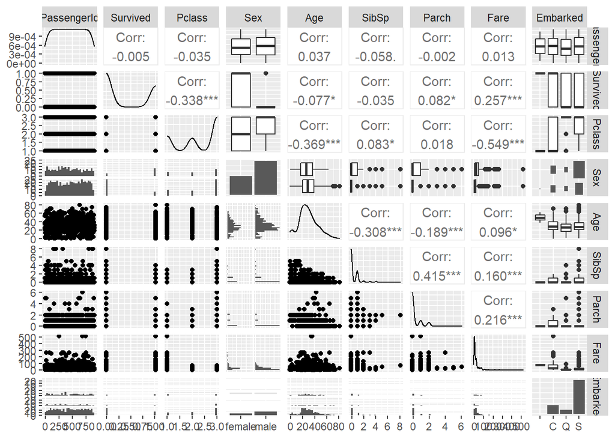

```r
ggp <- ggpairs(titanic_train[c(-4,-9, -11)])
print(ggp, progress = FALSE)
```

```r
titanic_train <- titanic_train[-4]
table(titanic_train$Survived) / sum(table(titanic_train$Survived))
```

```
##
##         0         1
## 0.6161616 0.3838384
```

# Сеточный поиск

```r
# Убираем пропуски
titanic_train <- na.omit(titanic_train)
# Отбираем наблюдения в обучающую выборку
set.seed(my.seed)
inTrain <- sample(seq_along(titanic_train$Survived),
                  nrow(titanic_train)*train.percent)
xtrain <- titanic_train[inTrain, c(-2, -8, -10, -11)]
xtest <- titanic_train[-inTrain, c(-2, -8, -10, -11)]
ytrain <- titanic_train[inTrain, 2]
ytest <- titanic_train[-inTrain, 2]

# Обучающая выборка
dat <- data.frame(x = xtrain, y = as.factor(ytrain))

# Тестовые данные
dat.te <- data.frame(x = xtest, y = as.factor(ytest))

# Параметры алгоритма
kernel.grid <- c('linear', 'polynomial')
cost.grid <- seq(1, 20, by = 0.5)

AUC <- matrix(0, length(kernel.grid), length(cost.grid))
colnames(AUC) <- paste0('cost = ', cost.grid)
rownames(AUC) <- paste0('kernel = ', kernel.grid)

# SVM
for (i in 1:length(kernel.grid)) {
    print(paste0('Starting ', kernel.grid[i], ' kernel'))
    for (j in 1:length(cost.grid)) {
        out <- svm(y ~ ., data = dat, kernel = kernel.grid[i],
                   cost = cost.grid[j])
        # Прогноз на тестовой выборке
        pred.te <- predict(out, newdata = dat.te)
        # Матрица неточностей
        tbl <- table(pred.te, dat.te$y)
        AUC[i, j] <- sum(diag(tbl)) / sum(tbl)
    }
}
```

```
## [1] "Starting linear kernel"
## [1] "Starting polynomial kernel"
```

```r
round(AUC, 3)
```

```
##                     cost = 1 cost = 1.5 cost = 2 cost = 2.5 cost = 3 cost = 3.5
## kernel = linear        0.804      0.804    0.804      0.804    0.804      0.804
## kernel = polynomial    0.771      0.788    0.793      0.799    0.810      0.821
##                     cost = 4 cost = 4.5 cost = 5 cost = 5.5 cost = 6 cost = 6.5
## kernel = linear        0.804      0.804    0.804      0.804    0.804      0.804
## kernel = polynomial    0.816      0.827    0.832      0.832    0.832      0.832
##                     cost = 7 cost = 7.5 cost = 8 cost = 8.5 cost = 9 cost = 9.5
## kernel = linear        0.804      0.804    0.804      0.804    0.804      0.804
## kernel = polynomial    0.827      0.821    0.821      0.816    0.816      0.804
##                     cost = 10 cost = 10.5 cost = 11 cost = 11.5 cost = 12
## kernel = linear         0.804       0.804     0.804       0.804     0.804
## kernel = polynomial     0.804       0.804     0.799       0.799     0.799
##                     cost = 12.5 cost = 13 cost = 13.5 cost = 14 cost = 14.5
## kernel = linear           0.804     0.804       0.804     0.804       0.804
## kernel = polynomial       0.793     0.799       0.799     0.799       0.799
##                     cost = 15 cost = 15.5 cost = 16 cost = 16.5 cost = 17
## kernel = linear         0.804       0.804     0.804       0.804     0.804
## kernel = polynomial     0.804       0.804     0.804       0.810     0.810
##                     cost = 17.5 cost = 18 cost = 18.5 cost = 19 cost = 19.5
## kernel = linear           0.804     0.804       0.804     0.804       0.804
## kernel = polynomial       0.810     0.816       0.804     0.804       0.804
##                     cost = 20
## kernel = linear         0.804
## kernel = polynomial     0.799
```

Из полученных результатов видно, что оптимальной формой ядерной функции будет полиномиальная модель.

# Оптимальное значение настроечного параметра

```r
# Классификатор на опорных векторах
svmfit <- svm(y ~ ., data = dat, kernel = "polynomial", cost = 6, cale = FALSE)

# Список опорных векторов
svmfit$index
```

```
##   [1]   1   3   7  11  13  19  29  30  32  36  39  41  44  49  59  65  71  77
##  [19]  85  93  95  96 101 103 107 110 111 113 114 115 116 117 119 126 133 134
##  [37] 136 138 142 143 145 161 167 180 184 186 187 189 196 197 200 201 205 206
##  [55] 217 218 221 230 232 239 240 243 245 248 249 253 255 257 260 268 278 288
##  [73] 292 295 300 305 307 311 314 316 317 320 327 334 351 353 357 358 360 373
##  [91] 384 390 392 394 396 397 413 414 419 421 424 427 428 429 431 434 442 443
## [109] 445 446 453 456 474 475 476 485 487 492 494 495 499 502 506 507 511 515
## [127] 517 518 521 529 532 535   4   5   6   9  10  15  17  18  33  35  42  46
## [145]  47  62  72  78  80  86  87  88  89  90  92 106 109 112 118 120 123 124
## [163] 127 128 131 146 151 152 156 158 160 164 165 168 170 171 173 179 182 185
## [181] 191 198 202 209 220 222 223 224 227 229 233 234 236 237 242 254 258 272
## [199] 273 275 281 285 286 290 291 296 297 299 302 306 309 323 324 325 338 347
## [217] 352 354 366 369 371 375 378 379 381 383 386 387 388 395 398 401 404 406
## [235] 407 408 415 417 430 433 440 441 448 450 452 454 455 457 458 459 460 466
## [253] 467 468 470 482 483 493 496 500 505 508 509 514 525 531
```

```r
# Сводка по модели
summary(svmfit)
```

```
##
## Call:
## svm(formula = y ~ ., data = dat, kernel = "polynomial", cost = 6,
##     cale = FALSE)
##
##
## Parameters:
##    SVM-Type:  C-classification
##  SVM-Kernel:  polynomial
##        cost:  6
##      degree:  3
##      coef.0:  0
##
## Number of Support Vectors:  266
##
##  ( 132 134 )
##
##
## Number of Classes:  2
##
## Levels:
##  0 1
```

```r
set.seed(my.seed)
tune.out <- tune(svm, y ~ ., data = dat, kernel = "polynomial",
                 ranges = list(cost = c(0.001, 0.1, 1, 5, 10, 100)))
summary(tune.out)
```

```
##
## Parameter tuning of 'svm':
##
## - sampling method: 10-fold cross validation
##
## - best parameters:
##  cost
##    10
##
## - best performance: 0.1983229
##
## - Detailed performance results:
##    cost     error dispersion
## 1 1e-03 0.4040182 0.08380033
## 2 1e-01 0.3237945 0.08969253
## 3 1e+00 0.2378057 0.09159166
## 4 5e+00 0.2078616 0.08229671
## 5 1e+01 0.1983229 0.06450308
## 6 1e+02 0.2058351 0.06093292
```

# Лучшая модель на всей обучающей выборке

```r
# Лучшая модель -- с минимальной ошибкой
bestmod <- tune.out$best.model
summary(bestmod)
```

```
##
## Call:
## best.tune(method = svm, train.x = y ~ ., data = dat, ranges = list(cost = c(0.001,
##     0.1, 1, 5, 10, 100)), kernel = "polynomial")
##
##
## Parameters:
##    SVM-Type:  C-classification
##  SVM-Kernel:  polynomial
##        cost:  10
##      degree:  3
##      coef.0:  0
##
## Number of Support Vectors:  254
##
##  ( 127 127 )
##
##
## Number of Classes:  2
##
## Levels:
##  0 1
```

```r
#
ypred_tr <- predict(bestmod, dat)

# Матрица неточностей
tbl1 <- table(Predicts = ypred_tr, Fact = dat$y)
tbl1
```

```
##         Fact
## Predicts   0   1
##        0 295  46
##        1  23 171
```

```r
# Чувствительность
TPR <- round(tbl1[2,2]/sum(tbl1[2,]),3)
TPR
```

```
## [1] 0.881
```

```r
# Специфичность
SPC <- round(tbl1[1,1]/sum(tbl1[1,]),3)
SPC
```

```
## [1] 0.865
```

```r
# Функция построения ROC-кривой: pred -- прогноз, truth -- факт
rocplot <- function(pred, truth, ...){
    predob = prediction(pred, truth)
    perf = performance(predob, "tpr", "fpr")
    plot(perf,...)}

# Оптимальная модель
svmfit.opt <- svm(y ~ ., data = dat, kernel = "polynomial",  cost = 10, probability = T)

# Матрица неточностей на обучающей (p = 0.01)
table(Predicts = predict(svmfit.opt, dat),
             Fact = dat$y)
```

```
##         Fact
## Predicts   0   1
##        0 295  46
##        1  23 171
```

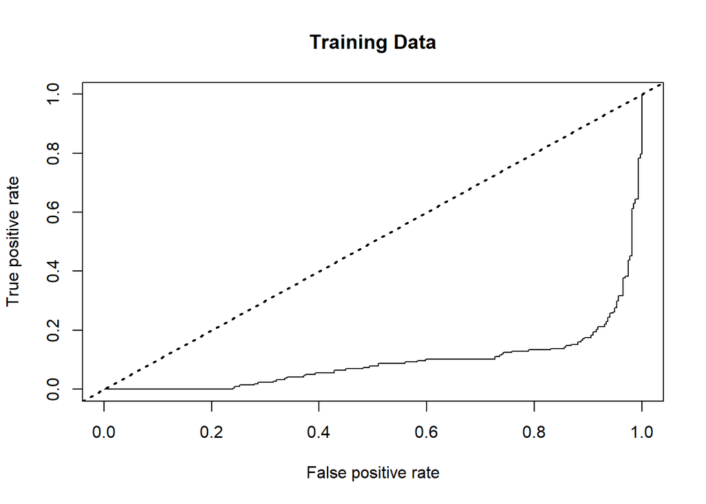

```r
# Прогноз вероятностей, на основе которых присваивается класс
fitted.prob <- predict(svmfit.opt, dat, type = "prob",  probability = TRUE)
fitted.prob <- attr(fitted.prob, "probabilities")[, 2]

# График для обучающей выборки
# ROC-кривая для первой модели
rocplot(fitted.prob, dat[, "y"], main = "Training Data")
# Прямая случайного классификатора
abline(a = 0, b = 1, lty = 3, lwd = 2)
```

# Лучшая модель на тестовой выборке

```r
# График для тестовой выборки
fitted.prob <- predict(svmfit.opt, dat.te, type = "prob",
                       probability = TRUE)
fitted.prob <- attr(fitted.prob, "probabilities")[, 2]

# Матрица неточностей на тестовой (p = 0.01)
tbl2 <- table(Predicts = predict(svmfit.opt, dat.te), Fact = dat.te$y)
tbl2
```

```
##         Fact
## Predicts  0  1
##        0 92 21
##        1 14 52
```

```r
# Точность
ACC <- round(sum(diag(tbl2))/sum(tbl2),3)
ACC
```

```
## [1] 0.804
```

```r
# Чувствительность
TPR <- round(tbl2[2,2]/sum(tbl2[2,]),3)
TPR
```

```
## [1] 0.788
```

```r
# Специфичность
SPC <- round(tbl2[1,1]/sum(tbl2[1,]),3)
SPC
```

```
## [1] 0.814
```

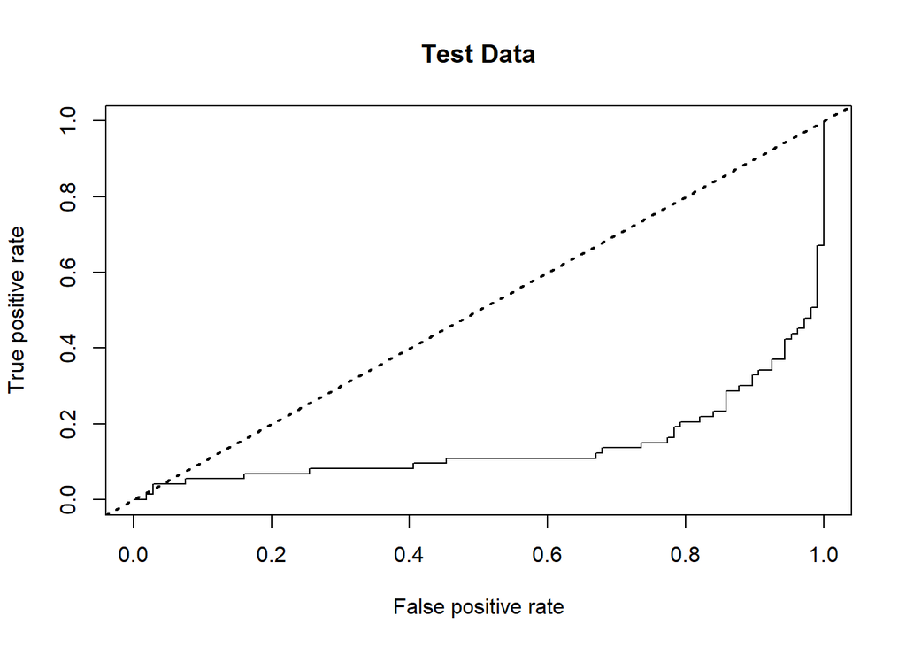

```r
# ROC-кривая для тестовой выборки
rocplot(fitted.prob, dat.te$y, main = "Test Data")
# Прямая случайного классификатора
abline(a = 0, b = 1, lty = 3, lwd = 2)
```

Как видно из графиков ROC-кривых, и для обучающей, и для тестовой выборок значение AUC менее 0.5, а значит классификатор действует с точностью до наоборот: если положительные классификации назвать отрицательными и наоборот, классификатор будет работать лучше. Учтём это при сравнении моделей на тестовой выборке.

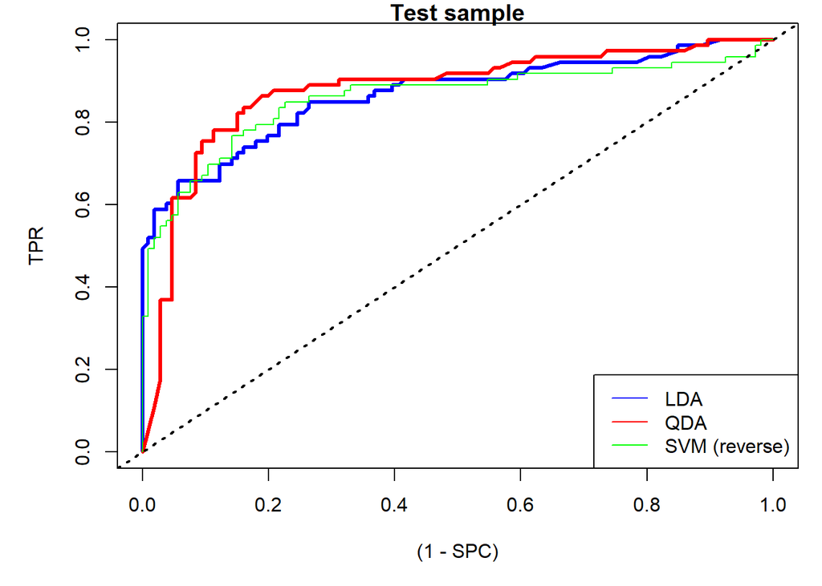

```r
# LDA
model.lda <- lda(y ~ ., data = dat)

# Прогноз: вероятности принадлежности классу Survived = 1

p.lda <- predict(model.lda, dat.te, type = 'response')

Forecast1 <- factor(ifelse(p.lda$posterior[, '1'] > 0.5, 2, 1), levels = c(1, 2), labels = c('0', '1'))

# Для (1 - SPC)
x1 <- NULL
# Для TPR
y1 <- NULL
# Заготовка под матрицу неточностей
tbl2 <- as.data.frame(matrix(rep(0, 4), 2, 2))
rownames(tbl2) <- c('fact.0', 'fact.1')
colnames(tbl2) <- c('predict.0', 'predict.1')
# Цикл по вероятностям отсечения
for (p in seq(0, 1, length = 501)){
  # Прогноз
  Forecast1 <- factor(ifelse(p.lda$posterior[, '1'] > p, 2, 1),
                      levels = c(1, 2),
                      labels = c('0', '1'))

  # фрейм со сравнением факта и прогноза
  df.compare <- data.frame(Fact = dat.te$y, Forecast = Forecast1)

  # Заполняем матрицу неточностей
  tbl2[1, 1] <- nrow(df.compare[df.compare$Fact == '0' & df.compare$Forecast == '0', ])
  tbl2[2, 2] <- nrow(df.compare[df.compare$Fact == '1' & df.compare$Forecast == '1', ])
  tbl2[1, 2] <- nrow(df.compare[df.compare$Fact == '0' & df.compare$Forecast == '1', ])
  tbl2[2, 1] <- nrow(df.compare[df.compare$Fact == '1' & df.compare$Forecast == '0', ])

  # Считаем характеристики
  TPR <- tbl2[2, 2] / sum(tbl2[2, ])
  y1 <- c(y1, TPR)
  SPC <- tbl2[1, 1] / sum(tbl2[1, ])
  x1 <- c(x1, 1 - SPC)
}

model.qda <- qda(y ~ ., data = dat)

# Прогноз: вероятности принадлежности классу Survived = 1
p.qda <- predict(model.qda, dat.te, type = 'response')

Forecast2 <- factor(ifelse(p.qda$posterior[, '1'] > 0.5, 2, 1), levels = c(1, 2), labels = c('0', '1'))

# Для (1 - SPC)
x2 <- NULL
# Для TPR
y2 <- NULL
# Заготовка под матрицу неточностей
tbl2 <- as.data.frame(matrix(rep(0, 4), 2, 2))
rownames(tbl2) <- c('fact.0', 'fact.1')
colnames(tbl2) <- c('predict.0', 'predict.1')
# Цикл по вероятностям отсечения
for (p in seq(0, 1, length = 501)){
  # Прогноз
  Forecast2 <- factor(ifelse(p.qda$posterior[, '1'] > p, 2, 1),
                      levels = c(1, 2),
                      labels = c('0', '1'))

  # фрейм со сравнением факта и прогноза
  df.compare <- data.frame(Fact = dat.te$y, Forecast = Forecast2)

  # Заполняем матрицу неточностей
  tbl2[1, 1] <- nrow(df.compare[df.compare$Fact == '0' & df.compare$Forecast == '0', ])
  tbl2[2, 2] <- nrow(df.compare[df.compare$Fact == '1' & df.compare$Forecast == '1', ])
  tbl2[1, 2] <- nrow(df.compare[df.compare$Fact == '0' & df.compare$Forecast == '1', ])
  tbl2[2, 1] <- nrow(df.compare[df.compare$Fact == '1' & df.compare$Forecast == '0', ])

  # Считаем характеристики
  TPR <- tbl2[2, 2] / sum(tbl2[2, ])
  y2 <- c(y2, TPR)
  SPC <- tbl2[1, 1] / sum(tbl2[1, ])
  x2 <- c(x2, 1 - SPC)
}

# строим ROC-кривую
par(mar = c(5, 5, 1, 1))

# кривая (LDA)
plot(x1, y1, type = 'l', col = 'blue', lwd = 3,
     xlab = '(1 - SPC)', ylab = 'TPR',
     xlim = c(0, 1), ylim = c(0, 1), main = 'Test sample')

# кривая (QDA)
lines(x2, y2, type = 'l', col = 'red', lwd = 3)

# кривая (SVM обр.)
rocplot(-fitted.prob, dat.te$y, add = T, col = 'green')

# прямая случайного классификатора
abline(a = 0, b = 1, lty = 3, lwd = 2)

# легенда
legend('bottomright', names <-  c('LDA', 'QDA', 'SVM (reverse)'), lty = 1, col = c('blue', 'red', 'green'))
```